# ***Exploratory Data Analysis on YouTube data***

# Exploratory Data Analysis on YouTube Dislikes Dataset

## Domain: Social Media

## Context and Content:

In a fairly recent move by Youtube, it announced the decision to hide the number of dislikes from users around November 2021. However, the official YouTube Data API allowed you to get information about dislikes until December 13, 2021. Doing an EDA-exercise can help to draw some unseen insights from this dataset.

## Learning Outcome:

- Exploratory Data Analysis using Pandas.

## Objective:

To do data analysis and explore the YouTube dislikes dataset using numpy and pandas libraries and drive meaningful insights by performing Exploratory data analysis.

## Data Description:

**YouTube Dislikes Dataset:**

- This dataset contains information about trending YouTube videos from August 2020 to December 2021 for the USA, Canada, and Great Britain.
- This dataset contains the latest possible information about dislikes, likes, views, and more which was collected just before December 13. The information was collected by videos that had been trending in the USA, Canada, and Great Britain for a year prior.
- Dataset link: [YouTube Dislikes Dataset](https://www.kaggle.com/datasets/dmitrynikolaev/youtube-dislikes-dataset)

# Attribute Information:

| SL.No | Column Name | Description |
| --- | --- | --- |
| 1 | Video ID | Unique video id. |
| 2 | Title Video | Video title. |
| 3 | Channel ID | Id of the channel. |
| 4 | Channel Title | Title of the channel. |
| 5 | Published at | Video publication date. |
| 6 | View count | Number of views. |
| 7 | Likes | Number of likes. |
| 8 | Dislikes | Number of dislikes. |
| 9 | Comment Count | Number of comments. |
| 10 | Tags | Tags (in one string). |
| 11 | Description | Video description. |
| 12 | Comments | 20 Video comments (in one string). |

# 1. Import required libraries and read the provided dataset (youtube_dislike_dataset.csv) and retrieve top 5 and bottom 5 records.

```python
#Importing Pandas library
import pandas as pd
import numpy as np
import os
import matplotlib.pyplot as plt
import seaborn as sns
```

```python
#Reading the DataSet
df = pd.read_csv("youtube_dislike_dataset.csv")
```

```python
#Retrieving top 5 records
df.head(5)
```

|  | video_id | title | channel_id | channel_title | published_at | view_count | likes | dislikes | comment_count | tags | description | comments |
| --- | --- | --- | --- | --- | --- | --- | --- | --- | --- | --- | --- | --- |
| 0 | --0bCF-iK2E | Jadon Sancho Magical Skills & Goals | UC6UL29enLNe4mqwTfAyeNuw | Bundesliga | 2021-07-01 10:00:00 | 1048888 | 19515 | 226 | 1319 | football soccer ftbol alemn Bundesliga season ... | Enjoy the best skills and goals from Jadon San... | Respect to Dortmund fans,must be sad losing hi... |
| 1 | --14w5SOEUs | Migos - Avalanche (Official Video) | UCGIelM2Dj3zza3xyV3pL3WQ | MigosVEVO | 2021-06-10 16:00:00 | 15352638 | 359277 | 7479 | 18729 | Migos Avalanche Quality Control Music/Motown R... | Watch the the official video for Migos - "Aval... | Migos just makes me want to live my live to th... |
| 2 | --40TEbZ9Is | Supporting Actress in a Comedy: 73rd Emmys | UClBKH8yZRcM4AsRjDVEdjMg | Television Academy | 2021-09-20 01:03:32 | 925281 | 11212 | 401 | 831 |  | Hannah Waddingham wins the Emmy for Supporting... | Hannah's energy bursts through any screen. Wel... |
| 3 | --4tfbSyYDE | JO1'YOUNG (JO1 ver.)' PERFORMANCE VIDEO | UCsmXiDP8S40uBeJYxvyulmA | JO1 | 2021-03-03 10:00:17 | 2641597 | 39131 | 441 | 3745 | PRODUCE101JAPAN JO1 TheSTAR STA... | JO1'YOUNG (JO1 ver.)' PERFORMANCE VIDEO\n\n---... | youngVer>< REN is really PERFECT. It's not ju... |
| 4 | --DKkzWVh-E | Why Retaining Walls Collapse | UCMOqf8ab-42UUQIdVoKwjlQ | Practical Engineering | 2021-12-07 13:00:00 | 715724 | 32887 | 367 | 1067 | retaining wall New Jersey highway Direct Conne... | One of the most important (and innocuous) part... | Keep up with all my projects here: https://pr... |

```python
#Retrieving bottom 5 records
df.tail(5)
```

|  | video_id | title | channel_id | channel_title | published_at | view_count | likes | dislikes | comment_count | tags | description | comments |
| --- | --- | --- | --- | --- | --- | --- | --- | --- | --- | --- | --- | --- |
| 37417 | zzd4ydafGR0 | Lil Tjay - Calling My Phone (feat. 6LACK) [Off... | UCEB4a5o_6KfjxHwNMnmj54Q | Lil Tjay | 2021-02-12 05:03:49 | 120408275 | 2180780 | 35871 | 81360 | Lil Tjay Steady Calling My Phone Calling My Ph... | Official video for "Calling My Phone" by Lil T... | 'DESTINED 2 WIN' OUT NOW !! https://liltjay.ln... |
| 37418 | zziBybeSAtw | PELICANS at LAKERS \| FULL GAME HIGHLIGHTS \| Ja... | UCWJ2lWNubArHWmf3FIHbfcQ | NBA | 2021-01-16 05:39:05 | 2841917 | 20759 | 1049 | 2624 | NBA G League Basketball game-0022000187 Lakers... | PELICANS at LAKERS \| FULL GAME HIGHLIGHTS \| Ja... | Montrezl Harrell is going crazy with the rebou... |
| 37419 | zzk09ESX7e0 | [MV] (MAMAMOO) - Where Are We Now | UCuhAUMLzJxlP1W7mEk0_6lA | MAMAMOO | 2021-06-02 09:00:10 | 13346678 | 720854 | 4426 | 90616 | MAMAMOO WAW WAW MAMAMOO WAW Where Are We Now... | [MV] (MAMAMOO) - Where Are We Now\n\nInstagra... | I honestly do not know why this song hit so ha... |
| 37420 | zzmQEb0Em5I | FELLIPE ESCUDERO- Master Podcast #12 | UC8NjnNWMsRqq11NYvHAQb1g | Master Podcast | 2020-10-20 20:59:30 | 252057 | 19198 | 1234 | 1471 | master masterpodcast lord lord vinheteiro z z ... | DOCTOR HAIR\nhttps://www.thedoctorhair.com/?fb... | Foi um prazer passar esta tarde com vocs debat... |
| 37421 | zzxPZwaA-8w | Gareth Bale brace secures dramatic comeback on... | UCEg25rdRZXg32iwai6N6l0w | Tottenham Hotspur | 2021-05-23 21:00:31 | 2252090 | 34063 | 868 | 2004 | Spurs Tottenham Hotspur Tottenham Leicester ... | Two minute highlights from Tottenham Hotspur's... | Thank you Kane for everything you have given t... |

# 2. Checking the info of the dataframe and write our inferences on data types and shape of the dataset

```python
df.info()
print(df.shape)
```

```
<class 'pandas.core.frame.DataFrame'>
RangeIndex: 37422 entries, 0 to 37421
Data columns (total 12 columns):
 #   Column         Non-Null Count  Dtype
---  ------         --------------  -----
 0   video_id       37422 non-null  object
 1   title          37422 non-null  object
 2   channel_id     37422 non-null  object
 3   channel_title  37422 non-null  object
 4   published_at   37422 non-null  object
 5   view_count     37422 non-null  int64
 6   likes          37422 non-null  int64
 7   dislikes       37422 non-null  int64
 8   comment_count  37422 non-null  int64
 9   tags           37422 non-null  object
 10  description    37422 non-null  object
 11  comments       37264 non-null  object
dtypes: int64(4), object(8)
memory usage: 3.4+ MB
(37422, 12)
```

**Data Types:**

**~ The dataset contains a total of 12 columns.**

**~ Object: Eight columns have object data type (object), which usually indicates text data: video_id, title, channel_id, channel_title, published_at, tags, description, and comments.**

**~ Integer:Four columns have integer data type (int64): view_count, likes, dislikes, and comment_count. .**

**Shape of data:**

**~ There are 37422 rows and 12 columns in the dataframe**

# 3. Checking for the Percentage of the missing values and droping or imputing them.

```python
(df.isnull().sum() /len(df)) * 100
```

```
video_id         0.000000
title            0.000000
channel_id       0.000000
channel_title    0.000000
published_at     0.000000
view_count       0.000000
likes            0.000000
dislikes         0.000000
comment_count    0.000000
tags             0.000000
description      0.000000
comments         0.422212
dtype: float64
```

**~ Only comments column has null values and that is 0.42% which are 158 missing values**

```python
# Dropped missing values in original dataset with the help of inplace=True,saved changes in the dataframe df.
df.dropna(inplace=True)
```

```python
# Verifying if all the missing values are dropped
df.isnull().sum()
```

```
video_id         0
title            0
channel_id       0
channel_title    0
published_at     0
view_count       0
likes            0
dislikes         0
comment_count    0
tags             0
description      0
comments         0
dtype: int64
```

# 4. Checking the statistical summary of both numerical and categorical columns and writing our inferences.

```python
#Only for numerical data type
df.describe().apply(lambda s: s.apply('{0:.5f}'.format))
```

|  | view_count | likes | dislikes | comment_count |
| --- | --- | --- | --- | --- |
| count | 37264.00000 | 37264.00000 | 37264.00000 | 37264.00000 |
| mean | 5710821.45003 | 167286.69700 | 4996.43412 | 9966.95315 |
| std | 24313037.50711 | 538493.10269 | 30751.93784 | 117346.46657 |
| min | 20368.00000 | 22.00000 | 3.00000 | 1.00000 |
| 25% | 514130.50000 | 13317.25000 | 282.75000 | 914.00000 |
| 50% | 1321860.50000 | 42556.00000 | 798.00000 | 2347.00000 |
| 75% | 3674527.25000 | 130966.50000 | 2466.25000 | 6212.00000 |
| max | 1322796924.00000 | 31837675.00000 | 2397733.00000 | 16071029.00000 |

**View Count:**

**~ The view_count column has a mean of approximately 5,710,821, indicating that, on average, videos in the dataset have over 5 million views.**

**~ The minimum number of views for a video is 20,368, and the maximum is 1,322,796,924.**

**~ The distribution of views is right-skewed, as the mean is greater than the median (50th percentile).**

**Likes:**

**~ The likes column has a mean of approximately 167,286, suggesting that, on average, videos have about 167,286 likes.**

**~The minimum number of likes for a video is 22, and the maximum is 31,837,675.**

**~For view_count, the distribution is right-skewed.**

**Dislikes:**

**~The dislikes column has a mean of approximately 4,996, indicating that, on average, videos have about 4,996 dislikes.**

**~The minimum number of dislikes for a video is 3, and the maximum is 2,397,733**

**~The distribution of dislikes is also right-skewed.**

**Comment Count:**

**~The comment_count column has a mean of approximately 9,966, suggesting that, on average, videos have about 9,966 comments.**

**~The minimum number of comments for a video is 1, and the maximum is 16,071,029.**

**~ The distribution of comment counts is right-skewed.**

```python
#we can also use df.describe(include="all") which includes summary statestics for both numeric and categorical variables
#however to maintain the clarity of code we've seperated the two variables
#Only for categorical(non-numeric) data type

df.describe(include='object')
```

|  | video_id | title | channel_id | channel_title | published_at | tags | description | comments |
| --- | --- | --- | --- | --- | --- | --- | --- | --- |
| count | 37264 | 37264 | 37264 | 37264 | 37264 | 37264 | 37264 | 37264 |
| unique | 37264 | 36958 | 10891 | 10813 | 36617 | 28705 | 35479 | 37264 |
| top | --0bCF-iK2E | www | UCNAf1k0yIjyGu3k9BwAg3lg | Sky Sports Football | 2020-10-16 04:00:10 |  |  | Respect to Dortmund fans,must be sad losing hi... |
| freq | 1 | 21 | 533 | 533 | 6 | 3808 | 587 | 1 |

**Count and Unique Values:**

**~ The video_id, title, channel_id, channel_title, tags, description, comments, and published_at columns all have 37,264 entries, indicating no missing values in these categorical columns.**

**~ The comments column has 37,264 unique values, suggesting that each video has a different set of comments.**

**Top and Frequency:**

**~ Top YouTube channel is Sky Sports Football**

**~ Top YouTube video title is www**

# 5. Converting datatype of column 'published_at' from object to pandas datetime.

```python
#conversion of datatype usng to_datetime()
df['published_at']=pd.to_datetime(df['published_at'])
df['published_at']
```

```
0       2021-07-01 10:00:00
1       2021-06-10 16:00:00
2       2021-09-20 01:03:32
3       2021-03-03 10:00:17
4       2021-12-07 13:00:00
                ...
37417   2021-02-12 05:03:49
37418   2021-01-16 05:39:05
37419   2021-06-02 09:00:10
37420   2020-10-20 20:59:30
37421   2021-05-23 21:00:31
Name: published_at, Length: 37264, dtype: datetime64[ns]
```

# 6. Creating a new column as 'published_month' using the column published_at (and displaying only the months)

```python
#using DatetimeIndex(dt.month) extracted month from 'published_at' column
df['published_at'].dt.month
```

```
0         7
1         6
2         9
3         3
4        12
         ..
37417     2
37418     1
37419     6
37420    10
37421     5
Name: published_at, Length: 37264, dtype: int32
```

```python
#The extracted value is then assigned to a new colum which is created by the name df['published_month'] and its contents displayed.
df['published_month']=df['published_at'].dt.month
df['published_month'].values                                    #the months are displayed along side their index value(we can use .value to extract only the values)
```

```
array([ 7,  6,  9, ...,  6, 10,  5])
```

# 7. Replace the numbers in the column published_month as names of the months i,e., 1 as 'Jan', 2 as 'Feb'and so on.....

```python
#Created a dictionary to save key-value pairs to be replaced, and then using replace function replaced months numbers to its values in dictionary
lib = {1:'Jan',2:'Feb',3:'Mar',4:'Apri',5:'May',6:'June',7:'July',8:'Aug',9:'Sep',10:'Oct',11:'Nov',12:'Dec'}

df['published_month'] = df['published_month'].replace(lib)  #we can also use the .map function to map the key value pairs from the dictionary into the dataframe
df['published_month']
```

```
0        July
1        June
2         Sep
3         Mar
4         Dec
         ...
37417     Feb
37418     Jan
37419    June
37420     Oct
37421     May
Name: published_month, Length: 37264, dtype: object
```

# 8. Find the number of videos published each month and arrange the months in a decreasing order based on the video count.

```python
#Here we've used the groupby to group the data based on the unique months and then did a count of 'video_id' associated to that particular month
#used .sort_values(ascending=False) the sort the values in descending order
# we can also use pd.pivot_table(df, index = ["published_month"], aggfunc="count", values="video_id") to represent this data and then sort them

df.groupby('published_month')['video_id'].count().sort_values(ascending=False)
```

```
published_month
Oct     4976
Sep     4854
Nov     4821
Aug     4250
Dec     3063
July    2331
June    2305
Mar     2248
Feb     2125
Apri    2119
Jan     2099
May     2073
Name: video_id, dtype: int64
```

**Findings:**

**~ Highest number of videos were published in the month of October (4976)**

**~ Lowest number of videos were published in the month of May (2073)**

# 9. Finding the count of unique video_id, channel_id and channel_title

```python
#To find count of unique video_id, channel_id and channel_title the nunique() function was called.
df[["video_id", "channel_id", "channel_title"]].nunique()
```

```
video_id         37264
channel_id       10891
channel_title    10813
dtype: int64
```

**Findings:**

**~ Number of unique values for video_id is the same as the total count of the videos**

**~ channel_id and channel_titles of more than 50% channels and videos are similar**

# 10. Find the top10 channel names having the highest number of videos in the dataset and the bottom10 having lowest number of videos.

```python
#gouping the data based on channel_title and counting the number of 'video_id' thereafter sorting the values in descending order
#we can also use pivot tables to represent this data:pd.pivot_table(df, index = ["channel_title"], aggfunc="count", values="video_id").sort_values(by=['video_id'], ascending=False)

channel_vid=df.groupby('channel_title')['video_id'].count().sort_values(ascending=False)
channel_vid
```

```
channel_title
Sky Sports Football    533
The United Stand       301
BT Sport               246
NBA                    209
NFL                    162
                      ...
Kaptain Kuba             1
Kanye West               1
Kannur kitchen           1
Kannada Cinema           1
zoom                     1
Name: video_id, Length: 10813, dtype: int64
```

```python
#from the sorted data extracting  the name of the top 10 records
channel_vid.head(10)
```

```
channel_title
Sky Sports Football    533
The United Stand       301
BT Sport               246
NBA                    209
NFL                    162
WWE                    122
SSSniperWolf            99
SSundee                 98
FORMULA 1               87
NHL                     86
Name: video_id, dtype: int64
```

```python
#from the sorted data extracting only the bottom 10 records
channel_vid.tail(10)
```

```
channel_title
Karikku Tuned      1
Karen Bustillos    1
Karen Aslanyan     1
Karchez            1
Karate Combat      1
Kaptain Kuba       1
Kanye West         1
Kannur kitchen     1
Kannada Cinema     1
zoom               1
Name: video_id, dtype: int64
```

**Findings:**

**~ The top-10 channels with the highest number of videos are : 'Sky Sports Football', 'The United Stand', 'BT Sport', 'NBA', 'NFL', 'WWE', 'SSSniperWolf', 'SSundee', 'FORMULA 1', 'NHL**

**~ The bottom-10 channels with the lowest number of videos are : 'Karikku Tuned', 'Karen Bustillos', 'Karen Aslanyan', 'Karchez', 'Karate Combat', 'Kaptain Kuba', 'Kanye West', 'Kannur kitchen', 'Kannada Cinema', 'zoom'**

# 11. Find the title of the video which has the maximum number of likes and the title of the video having minimum likes and write your inferences.

```python
#using groupby to group the title of the video and aggregating the sum of likes for the particular channel_title
#we can also use pivot tables to do the same
title_likes=df.groupby('title')['likes'].sum().sort_values(ascending=False)
title_likes
```

```
title
BTS () 'Dynamite' Official MV                      31837675
BTS () 'Butter' Official MV                        20649409
BLACKPINK - 'Ice Cream (with Selena Gomez)' M/V    17864527
BTS () 'Life Goes On' Official MV                  16354127
BTS () 'Permission to Dance' Official MV           15449003
                                                     ...
Virtual Pub Quiz, Live! Thursday 8th July               106
Virtual Pub Quiz, Live! Saturday 12th December           97
Small Business Loans from OnDeck                         29
Tims For Good: A Taste Of The Familiar                   28
Leading the Charge | Circle K                            22
Name: likes, Length: 36958, dtype: int64
```

```python
title_likes.head(1).index
```

```
Index(['BTS () 'Dynamite' Official MV'], dtype='object', name='title')
```

```python
title_likes.tail(1).index
```

```
Index(['Leading the Charge | Circle K'], dtype='object', name='title')
```

**Findings:**

**~ The title of the video which has the maximum number of likes is:"BTS () 'Dynamite' Official MV" with '31837675' likes**

**~ The title of the video which has the minimum number of likes is:"Leading the Charge | Circle K" with '22' likes**

# 12. Find the title of the video which has the maximum number of dislikes and the title of the video having minimum dislikes and write your inferences.

```python
#using groupby to group the title of the video and aggregating the sum of dislikes for the particular channel_title
#we can also use pivot tables to do the same
title_dislikes=df.groupby('title')['dislikes'].sum().sort_values(ascending=False)
title_dislikes
```

```
title
Cuties | Official Trailer | Netflix                                                                 2397733
BTS () 'Dynamite' Official MV                                                                       1814333
Cardi B - WAP feat. Megan Thee Stallion [Official Music Video]                                      1331181
52 GAJ KA DAMAN | PRANJAL DAHIYA | AMAN JAJI | RENUKA PANWAR  | MUKESH JAJI | SAHIL SANDHU          1259533
BLACKPINK - 'Ice Cream (with Selena Gomez)' M/V                                                     1253187
                                                                                                     ...
Leicester v Gloucester | Wigglesworth Impresses on Leicester Debut | Gallagher Premiership Rugby          7
YONEX Thailand Open | Day 3: Saina Nehwal (IND) vs. Busanan Ongbamrungphan (THA)                          7
Leeds Rhinos vs Wakefield Trinity | Super League Full Match                                               6
Live Stream: Hampshire v Yorkshire - LV= County Championship, Day Four                                    4
Tims For Good: A Taste Of The Familiar                                                                    3
Name: dislikes, Length: 36958, dtype: int64
```

```python
title_dislikes.head(1).index
```

```
Index(['Cuties | Official Trailer | Netflix'], dtype='object', name='title')
```

```python
title_dislikes.tail(1).index
```

```
Index(['Tims For Good: A Taste Of The Familiar'], dtype='object', name='title')
```

**Findings:**

**~ The title of the video which has the maximum number of dislikes is:"Cuties | Official Trailer | Netflix" with '2397733' dislikes**

**~ The title of the video which has the minimum number of dislikes is:"Tims For Good: A Taste Of The Familiar" with '3' dislikes**

# 13. Does the number of views have any effect on how many people disliked the video? Support your answer with a metric and a plot.

```python
#Creating correlation matrix to find out corrlation between view_count and dislikes using .corr()
df[["view_count","dislikes"]].corr()
```

|  | view_count | dislikes |
| --- | --- | --- |
| view_count | 1.000000 | 0.684576 |
| dislikes | 0.684576 | 1.000000 |

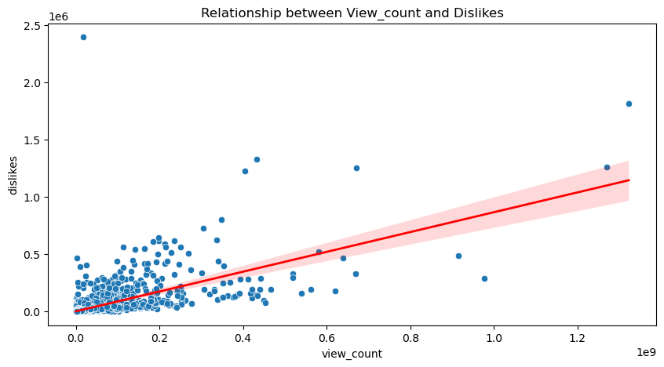

```python
plt.figure(figsize=(10, 5))
sns.scatterplot(data=df,x='view_count',y='dislikes')
sns.regplot(data=df, x='view_count', y='dislikes', scatter=False, color='red', line_kws={'linewidth': 2})
plt.title('Relationship between View_count and Dislikes')
plt.show()
```

**Findings:**

**~ From the correlation matrix we can see that there is positive correlation of .68 between "views" and "dislikes".**

# 14. Display all the information about the videos that were published in January, and mention the count of videos that were published in January.

```python
#With this query we can extract the videos that were published in the month of January
#we can also use slicers to do the same df[df["published_month"]=="Jan"]
df.query('published_month == "Jan" ')
```

|  | video_id | title | channel_id | channel_title | published_at | view_count | likes | dislikes | comment_count | tags | description | comments | published_month |
| --- | --- | --- | --- | --- | --- | --- | --- | --- | --- | --- | --- | --- | --- |
| 27 | -2Gwm7QfBnE | Q&A With Naisha | UCYwNMbogQFzMccPSuy-pPWg | MianTwins | 2021-01-21 00:05:47 | 872372 | 38626 | 239 | 621 |  | Hey Guys!!! this has been the most requested v... | I feel like Nate and Aishas personality match ... | Jan |
| 48 | -4sfXSHSxzA | SURPRISING BRENT WITH HIS TIKTOK CRUSH!! | UCPpATKqmMV-CNRNWYaDUwiA | Alexa Rivera | 2021-01-16 21:40:04 | 6504784 | 262477 | 5779 | 7907 |  | He had no idea! Thank you guys so much for wat... | Thank you guys for watching and don't forget t... | Jan |
| 95 | -AJD1Fc5rpQ | WE ARE HAVING A BABY! \| finding out i'm pregna... | UCVsTboAhpnuL6j-tDePvNwQ | Tess Christine | 2021-01-03 21:53:48 | 533084 | 38965 | 119 | 1650 |  | I am so happy to tell you that I am pregnant!!... | Okay I needed a moment to collect my thoughts ... | Jan |
| 103 | -AuJiwjsmWk | Do Ugly Foods Taste Worse? Taste Test | UCzpCc5n9hqiVC7HhPwcIKEg | Good Mythical MORE | 2021-01-19 11:00:01 | 1057077 | 22526 | 531 | 773 | gmm good mythical morning rhettandlink rhett a... | Today, we're doing a blind taste test to deter... | "there's nothing wrong with it being bent"\nI ... | Jan |
| 182 | -JhqO2KWr5U | Schlatt gets fit | UCWZp4y1jqBuvLtiyxSs_ZBw | Big guy | 2021-01-24 22:50:57 | 1724965 | 119431 | 325 | 1578 | jschlatt big guy jschlatt highlights schlatt j... | #jschlatt #schlatt #bigguy #short | Schlatt is single handedly wiping out all the ... | Jan |
| ... | ... | ... | ... | ... | ... | ... | ... | ... | ... | ... | ... | ... | ... |
| 37300 | zmzFL5bG-jc | DEVINE MON PERSONNAGE AVANT AKINATOR ! (c'est ... | UCIlr3byh6wmXgcPx_Tm9Ocw | Piwerre | 2021-01-16 16:12:19 | 670357 | 54462 | 832 | 1249 | Piwerre frere de michou crouton among us devin... | Discord Piwerre : https://discord.gg/QBduPgAA... | Mdr michou quand c'est pas ses tournage il fou... | Jan |
| 37329 | zpzjex7qwrA | Lampard Sacked Within Days Rorys Misery \| Chel... | UCkD-ZOixI0a9FjIExDsHsbg | The Kick Off | 2021-01-03 20:13:49 | 428646 | 12060 | 296 | 1505 | Premier league Chelsea chelsea 1-3 Man City Ch... | The Kick Off watched Manchester City destroy C... | True Its like a fighter who Geordie But I thou... | Jan |
| 37345 | zqyv-B6mnBM | Lil Wayne - Ain't Got Time (Audio) | UCO9zJy7HWrIS3ojB4Lr7Yqw | Lil Wayne | 2021-01-21 05:00:10 | 2238244 | 58925 | 2365 | 5539 | lil wayne weezy weezy wednesday wayne carter y... | Official audio for Lil Wayne "Ain't Got Time",... | RIP Juice Wrld, wrote that on two cups, pour o... | Jan |
| 37383 | zwfu1-24T7Q | PRADA Cup Day 1 \| Full Race Replay \| PRADA Cup... | UCo15ZYO_XDRU9LI30OPtxAg | America's Cup | 2021-01-15 04:07:55 | 317382 | 2008 | 83 | 192 | America's Cup Americas Cup AC36 AC75 Presented... | The opening day of the PRADA Cup in Auckland, ... | Incredible how these boats evolve in a short t... | Jan |
| 37418 | zziBybeSAtw | PELICANS at LAKERS \| FULL GAME HIGHLIGHTS \| Ja... | UCWJ2lWNubArHWmf3FIHbfcQ | NBA | 2021-01-16 05:39:05 | 2841917 | 20759 | 1049 | 2624 | NBA G League Basketball game-0022000187 Lakers... | PELICANS at LAKERS \| FULL GAME HIGHLIGHTS \| Ja... | Montrezl Harrell is going crazy with the rebou... | Jan |

2099 rows × 13 columns

```python
#using the nunique() method to count the unique video_id published in the month of January
Jan_vid=df.query('published_month == "Jan" ')
Jan_vid['video_id'].nunique()
```

```
2099
```

**Findings:**

**~ In January 2099 videos were published .**